# Sampling & Processing GSV Images

# Step 3. Extract start, mid, and end points of each segment. For those points, calculate the azimuth.

We will download four images for street segment, one at the start of a segment, two in the middle of a segment (each looking opposite to the other), and one at the end of a segment. The code below, we will extract a street segment (i.e., `e` below) and demonstrate how to calculate azimuth for the start point, end point, and mid point.

```r
# Select an edge for demo
test_edge = 23126
e <- edges %>% filter(edge_id == test_edge)

# View it
tmap_mode('view')
```

```
## tmap mode set to interactive viewing
```

```r
e %>% st_coordinates() %>%
  as.data.frame() %>%
  st_as_sf(coords = c("X", "Y"), crs = 4326) %>%
  with(
    tm_shape(.) + tm_dots() +
    tm_shape(.[1,]) + tm_dots(col = "red") +  # Start = red
      tm_shape(.[nrow(.),]) + tm_dots(col = "yellow")  # End = yellow
  )
```

[interactive chart not shown]

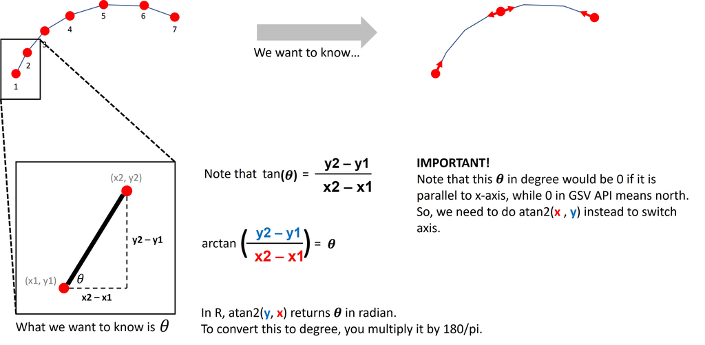

```r
# -----------------------------------------------------------
# First intersection
# First two points from a line
start_p <- e %>%
  st_coordinates() %>%
  .[1:2,1:2]

# Calculate the azimuth of the line connecting the two points
start_azi <- atan2(start_p[2,"X"] - start_p[1, "X"],
                   start_p[2,"Y"] - start_p[1, "Y"])*180/pi # 180/pi because trigonometry in R takes radians

# -----------------------------------------------------------
# The other intersection
# Last two points from a line
end_p <- e %>%
  st_coordinates() %>%
  .[(nrow(.)-1):nrow(.),1:2]

# Calculate the azimuth of the line connecting the two points
end_azi <- atan2(end_p[2,"X"] - end_p[1, "X"],
                 end_p[2,"Y"] - end_p[1, "Y"])*180/pi

# Flip the azimuth so that the camera would be looking back
end_azi <- if (end_azi < 180) {end_azi + 180} else {end_azi - 180}

# ----------------------------------------------------------
# mid point
mid_p <- e %>%
  st_geometry() %>%
  .[[1]] %>%
  st_line_sample(sample = c(0.45, 0.55)) %>%
  st_cast("POINT") %>%
  st_coordinates()

mid_azi <- atan2(mid_p[2,"X"] - mid_p[1, "X"],
                 mid_p[2,"Y"] - mid_p[1, "Y"])*180/pi

mid_p <- e %>%
  st_geometry() %>%
  .[[1]] %>%
  st_line_sample(sample = 0.5) %>%
  st_coordinates() %>%
  .[1,1:2]
```

# Step 4. Define a function that performs Step 3.

```r
get_azi <- function(line){
  # end point 1 ----------------------------------------------
  start_p <- line %>%
  st_coordinates() %>%
  .[1:2,1:2]

  start_azi <- atan2(start_p[2,"X"] - start_p[1, "X"],
                     start_p[2,"Y"] - start_p[1, "Y"])*180/pi

  # end point 2 ----------------------------------------------
  end_p <- line %>%
    st_coordinates() %>%
    .[(nrow(.)-1):nrow(.),1:2]

  end_azi <- atan2(end_p[2,"X"] - end_p[1, "X"],
                   end_p[2,"Y"] - end_p[1, "Y"])*180/pi

  end_azi <- if (end_azi < 180) {end_azi + 180} else {end_azi - 180}

  # mid point 1 ---------------------------------------------
  mid_p <- line %>%
    st_line_sample(sample = c(0.45, 0.55)) %>%
    st_cast("POINT") %>%
    st_coordinates()

  mid_azi <- atan2(mid_p[2,"X"] - mid_p[1, "X"],
                   mid_p[2,"Y"] - mid_p[1, "Y"])*180/pi

  mid_p <- line %>%
    st_line_sample(sample = 0.5) %>%
    st_coordinates() %>%
    .[1,1:2]


  # return in data frame ------------------------------------
  return(tribble(
    ~type,    ~X,            ~Y,             ~azi,
    "start",   start_p[1,"X"], start_p[1,"Y"], start_azi,
    "mid1",    mid_p["X"],   mid_p["Y"],   mid_azi,
    "mid2",    mid_p["X"],   mid_p["Y"],   ifelse(mid_azi < 180, mid_azi + 180, mid_azi - 180),
    "end",     end_p[2,"X"],   end_p[2,"Y"],   end_azi))
}
```

# Step 5. Apply the function to all street segments

```r
endp_azi <- edges %>%
  st_geometry() %>%
  map_df(get_azi)

endp <- endp_azi %>%
  bind_cols(edges %>%
              st_drop_geometry() %>%
              slice(rep(1:nrow(edges),each=4))) %>%
  st_as_sf(coords = c("X", "Y"), crs = 4326, remove=FALSE) %>%
  mutate(node_id = seq(1, nrow(.)))

endp
```

```
## Simple feature collection with 106636 features and 9 fields
## Geometry type: POINT
## Dimension:     XY
## Bounding box:  xmin: -84.5767 ymin: 33.62933 xmax: -84.25214 ymax: 33.90885
## Geodetic CRS:  WGS 84
## # A tibble: 106,636 × 10
##    type      X     Y    azi osm_id  highway     length edge_id
##  * <chr> <dbl> <dbl>  <dbl> <chr>   <chr>        <dbl>   <int>
##  1 start -84.3  33.7 -151.  9109755 tertiary      189.       1
##  2 mid1  -84.3  33.7 -155.  9109755 tertiary      189.       1
##  3 mid2  -84.3  33.7   25.0 9109755 tertiary      189.       1
##  4 end   -84.3  33.7   24.9 9109755 tertiary      189.       1
##  5 start -84.3  33.7 -150.  9109755 tertiary      936.       2
##  6 mid1  -84.3  33.7 -124.  9109755 tertiary      936.       2
##  7 mid2  -84.3  33.7   55.9 9109755 tertiary      936.       2
##  8 end   -84.3  33.6   20.6 9109755 tertiary      936.       2
##  9 start -84.3  33.6   60.6 9112693 residential   449.       3
## 10 mid1  -84.3  33.6   40.8 9112693 residential   449.       3
## # ℹ 106,626 more rows
## # ℹ 2 more variables: geometry <POINT [°]>, node_id <int>
```

# Step 6. Define a function that formats request URL and download images.

```r
get_image <- function(iterrow){
  type = iterrow$type
  location <- paste0(iterrow$Y %>% round(4), ",", iterrow$X %>% round(4))
  heading <- iterrow$azi %>% round(1)
  edge_id <- iterrow$edge_id
  node_id <- iterrow$node_id
  highway <- iterrow$highway
  key <- Sys.getenv("google_api")

  furl <- glue::glue("https://maps.googleapis.com/maps/api/streetview?size=640x640&location={location}&heading={heading}&fov=90&pitch=0&key={key}")
  fname <- glue::glue("GSV-nid_{node_id}-eid_{edge_id}-type_{type}-Location_{location}-heading_{heading}-highway_{highway}.jpg")
  fpath <- here("Lab", "module_4", "downloaded_image", fname)
  download.file(furl, fpath, mode = 'wb')
}
```

To reduce the number of images you’d be downloading, I pre-filtered the points so that it includes only Atlantic Station. Download endp_atlantic_station.geojson from [here](https://raw.githubusercontent.com/ujhwang/UrbanAnalytics2023/main/Lab/module_4/endp_atlantic_station.geojson).

```r
# Download images
edges_as <- st_read("https://raw.githubusercontent.com/ujhwang/UrbanAnalytics2023/main/Lab/module_4/endp_atlantic_station.geojson")
# Loop!
for (i in seq(1,nrow(edges_as))){
  get_image(edges_as[i,])
}
```

> ZIP THE DOWNLOADED IMAGES AND NAME IT ‘gsv_images.zip’ FOR THE SUBSEQUENT ANALYSIS.

# Another way to sample GSV images

Previously, we sampled four points per street segment. However, other studies have used different methods of sampling GSV images. One of the most widely used sampling method is to download one panoramic image at some fixed distance interval, such as 20 meters. This can be easily achieved by a small change to the code shown above.

Here, two sets of points are generated, (1) for actual location of points and (2) for the azimuth calculation. Notice that the points for azimuth calculation (i.e., 2) are twice as many as the points for actual location (i.e., 1).

```r
# Extract a curvy line
z <- edges %>% filter(edge_id == test_edge)
tm_shape(z) + tm_lines()
```

[interactive chart not shown]

```r
# calculate what proportion equals 40 in the given segment
prop <- 40/z$length

# Vector for actual points
sample_actual <- c(seq(0, 1, by=prop),1)

# Vector for two points before/after the actual points for azimuth calculation
sample_azi <- c(sample_actual-0.02, sample_actual+0.02) %>% sort()

# Sample points
sampled_actual <- z %>% st_transform(26967) %>% st_line_sample(sample = sample_actual) %>% st_cast("POINT")
sampled_azi <- z %>% st_transform(26967) %>% st_line_sample(sample = sample_azi) %>% st_cast("POINT")
# View them
tm_shape(sampled_actual) + tm_dots(col = "red", size=0.07) +
  tm_shape(sampled_azi) + tm_dots(col = "blue", alpha = 0.5)
```

[interactive chart not shown]

```r
# Calculate azimuth
point_azi <- sampled_actual %>%
  st_sf() %>%
  mutate(azi = NA)

for (i in 1:nrow(point_azi)){
  j <- i*2 - 1
  point_azi[i, "azi"] <- sampled_azi %>%
    st_cast("POINT") %>%
    .[j:(j+1)] %>%
    st_coordinates() %>%
    as.data.frame() %>%
    with(
      .[2,] - .[1,]
    ) %>%
    with(
      atan2(.[["X"]], .[["Y"]])*180/pi
    )
}
```